# R Markdown for HW2

Modestos A. Modestou

2025-03-17

## R Markdown

This is an R Markdown document for the R assignment (HW2) in BCB546.

# *Part I - Data Inspection*

**1.** **fang_et-al_genotypes**:

```r
fang_et_al_genotypes <- read_delim("Common_files/fang_et_al_genotypes.txt",
    delim = "\t", escape_double = FALSE,
    trim_ws = TRUE)
```

Ordered lists:

1. The file has one header line
2. It contains 2782 lines (excluding the header line) and 986 columns

```r
file_size_mb <- file.size("Common_files/fang_et_al_genotypes.txt") / (1024 * 1024)
print(paste("File size:", round(file_size_mb, 2), "MB"))
```

```
## [1] "File size: 10.54 MB"
```

3. The size of the file is 10.54 MB (Megabytes)
4. Display the first six lines of the file

```r
data <- read.delim("Common_files/fang_et_al_genotypes.txt", sep = "\t", header = TRUE)
head(data)
```

[output not shown]

5. Display the last six lines of the file

```r
data <- read.delim("Common_files/fang_et_al_genotypes.txt", sep = "\t", header = TRUE)
tail(data)
```

[output not shown]

**2.** **snp_position**:

```r
snp_position <- read_delim("Common_files/snp_position.txt",
    delim = "\t", escape_double = FALSE,
    trim_ws = TRUE)
```

Ordered lists:

1. The file has one header line
2. It contains 983 lines (excluding the header line) and 15 columns

```r
file_size_mb <- file.size("Common_files/snp_position.txt") / 1024
print(paste("File size:", round(file_size_mb, 2), "KB"))
```

```
## [1] "File size: 80.82 KB"
```

3. The size of the file is 80.82 KB (Kilobytes)
4. Display the first six lines of the file

```r
data <- read.delim("Common_files/snp_position.txt", sep = "\t", header = TRUE)
head(data)
```

[output not shown]

5. Display the last six lines of the file

```r
data <- read.delim("Common_files/snp_position.txt", sep = "\t", header = TRUE)
tail(data)
```

[output not shown]

# *Part II - Data Processing*

## Common Data for Maize and Teosinte

1. Remove the first two lines (i.e., the header line and the first line) from the provided file transposed_genotypes.txt and save the new file as transposed_oneheader.txt in Common_files.

```r
lines <- readLines("Common_files/transposed_genotypes.txt")
lines <- lines[-c(1, 2)]
writeLines(lines, "Common_files/transposed_oneheader.txt")
```

2. Replace “Group” with “SNP_ID” in the header line of the file transposed_oneheader.txt and save the new file as transposed_editedheader.txt in Common_files.

```r
lines <- readLines("Common_files/transposed_oneheader.txt")
lines <- gsub("Group", "SNP_ID", lines)
writeLines(lines, "Common_files/transposed_editedheader.txt")
```

3. Join the tab-delimited files snp_position.txt and transposed_editedheader.txt based on their first column and save the result to joined_unedited.txt in Common_files.

```r
snp_position <- read.delim("Common_files/snp_position.txt", header = TRUE, sep = "\t")
transposed_editedheader <- read.delim("Common_files/transposed_editedheader.txt", header = TRUE, sep = "\t")
joined_data <- inner_join(snp_position, transposed_editedheader, by = colnames(snp_position)[1])
write.table(joined_data, "Common_files/joined_unedited.txt", sep = "\t", row.names = FALSE, quote = FALSE)
```

4. Remove the second column from the joined_unedited.txt and save the output into joined_final.txt in Common_files.

```r
data <- fread("Common_files/joined_unedited.txt", sep = "\t", header = TRUE)
data <- data[, -2, with = FALSE]
fwrite(data, "Common_files/joined_final.txt", sep = "\t", quote = FALSE)
```

### Data for Maize

1. Filter column names containing “ZMMIL” in the file joined_final.txt and save the output to the new file ZMMIL.txt in Common_files.

```r
header <- fread("Common_files/joined_final.txt", nrows = 1, header = FALSE, sep = "\t")
header_dt <- data.table(Index = seq_along(header), Column = as.character(unlist(header)))
zmmil_dt <- header_dt[grepl("Common_files/ZMMIL", Column)]
fwrite(zmmil_dt, "Common_files/ZMMIL.txt", sep = "\t", quote = FALSE, col.names = FALSE)
```

2. Filter column names containing “ZMMLR” in the file joined_final.txt and save the output to the new file ZMMLR.txt in Common_files.

```r
header <- fread("Common_files/joined_final.txt", nrows = 1, header = FALSE, sep = "\t")
header_dt <- data.table(Index = seq_along(header), Column = as.character(unlist(header)))
zmmlr_dt <- header_dt[grepl("Common_files/ZMMLR", Column)]
fwrite(zmmlr_dt, "Common_files/ZMMLR.txt", sep = "\t", quote = FALSE, col.names = FALSE)
```

3. Filter column names containing “ZMMMR” in the file joined_final.txt and save the output to the new file ZMMMR.txt in Common_files.

```r
header <- fread("Common_files/joined_final.txt", nrows = 1, header = FALSE, sep = "\t")
header_dt <- data.table(Index = seq_along(header), Column = as.character(unlist(header)))
zmmmr_dt <- header_dt[grepl("Common_files/ZMMMR", Column)]
fwrite(zmmmr_dt, "Common_files/ZMMMR.txt", sep = "\t", quote = FALSE, col.names = FALSE)
```

4. Extract the specified columns from joined _final.txt and save the output in maize_data.txt in the Common_files.

```r
data <- fread("Common_files/joined_final.txt", sep = "\t", header = TRUE)
selected_columns <- c(1, 2, 3, 1224:2479, 2480:2506, 2507:2796)
maize_data <- data[, ..selected_columns]
fwrite(maize_data, "Common_files/maize_data.txt", sep = "\t", quote = FALSE)
```

5. Sort maize_data.txt numerically by column 2, i.e., chromosome column, while keeping the header intact and then save the sorted output to sorted_maize.txt in Common_files.

```r
file_path <- "Common_files/maize_data.txt"
data <- fread(file_path, sep = "\t", header = TRUE)
col_name <- grep("^Chromosome$", names(data), value = TRUE)
data[, (col_name) := suppressWarnings(as.numeric(get(col_name)))]
data <- data[!is.na(get(col_name))]
sorted_data <- data[order(get(col_name)), ]
output_path <- "Common_files/sorted_maize.txt"
fwrite(sorted_data, output_path, sep = "\t", quote = FALSE)
```

6. This loop extracts rows where column 2 equals a specific value ($i) from sorted_maize.txt and saves the filtered data into separate files (maize_chr01.txt, maize_chr02.txt, …, maize_chr10.txt), preserving the header in each file. The individual files are saved in Common_files.

```r
file_path <- "Common_files/sorted_maize.txt"
data <- fread(file_path, sep = "\t", header = TRUE)
# Loop through chromosome values (1 to 10) and create separate files
for (i in 1:10) {
  # Filter rows where Chromosome == i
  subset_data <- data[get(col_name) == i]
  if (nrow(subset_data) > 0) {
    output_file <- file.path("Common_files", sprintf("maize_chr%02d.txt", i))
    fwrite(subset_data, output_file, sep = "\t", quote = FALSE)
  }
}
```

### Final Data for Maize

1. This loop goes through the maize_chr01.txt to maize_chr10.txt files, sorts each file numerically in increasing order by column 3 while keeping the header intact, and saves the sorted output to Maize_Sorted_Increasing.

```r
input_dir <- "Common_files"
output_dir <- "Maize_Sorted_Increasing"
# Loop through maize_chr01.txt to maize_chr10.txt
for (i in 1:10) {
# Construct input and output file paths
  input_file <- file.path(input_dir, sprintf("maize_chr%02d.txt", i))
  output_file <- file.path(output_dir, sprintf("maize_chr%02d.txt", i))
# Read data, preserving the header
    data <- fread(input_file, sep = "\t", header = TRUE)
# Identify the actual name of column 3
  col_pos <- colnames(data)[3]
# Ensure that column 3 ("Position") is converted to a numeric format
    data[[col_pos]] <- suppressWarnings(as.numeric(data[[col_pos]]))
# Remove NA values and sort by column 3 in increasing order
    sorted_data <- data[!is.na(get(col_pos)), ][order(get(col_pos)), ]
# Write the sorted file to the new directory
    fwrite(sorted_data, output_file, sep = "\t", quote = FALSE)
  }
```

2. This loop goes through the maize_chr01.txt to maize_chr10.txt files, sorts each file numerically in decreasing order by column 3 while keeping the header intact, and replaces ?/? with -/- in the output. The sorted output is then saved in Maize_Sorted_Decreasing.

```r
input_dir <- "Common_files"
output_dir <- "Maize_Sorted_Decreasing"
# Loop through maize_chr01.txt to maize_chr10.txt
for (i in 1:10) {
# Construct input and output file paths
  input_file <- file.path(input_dir, sprintf("maize_chr%02d.txt", i))
  output_file <- file.path(output_dir, sprintf("maize_chr%02d.txt", i))
# Read data, preserving the header
    data <- fread(input_file, sep = "\t", header = TRUE)
# Identify the actual name of column 3
  col_pos <- colnames(data)[3]
# Ensure that column 3 ("Position") is converted to a numeric format
    data[[col_pos]] <- suppressWarnings(as.numeric(data[[col_pos]]))
# Replace '?/? with '-/-'
    data <- data[, lapply(.SD, function(x) gsub("\\?/\\?", "-/-", x)), .SDcols = names(data)]
# Remove NA values and sort by column 3 in decreasing order
    sorted_data <- data[!is.na(get(col_pos)), ][order(-get(col_pos)), ]
# Write the sorted file to the new directory
    fwrite(sorted_data, output_file, sep = "\t", quote = FALSE)
  }
```

### Data for Teosinte

1. Filter column names containing “ZMPBA” in the file joined_final.txt and save the output to the new file ZMPBA.txt in Common_files.

```r
header <- fread("Common_files/joined_final.txt", nrows = 1, header = FALSE, sep = "\t")
header_dt <- data.table(Index = seq_along(header), Column = as.character(unlist(header)))
zmpba_dt <- header_dt[grepl("Common_files/ZMPBA", Column)]
fwrite(zmpba_dt, "Common_files/ZMPBA.txt", sep = "\t", quote = FALSE, col.names = FALSE)
```

2. Filter column names containing “ZMPIL” in the file joined_final.txt and save the output to the new file ZMPIL.txt in Common_files.

```r
header <- fread("Common_files/joined_final.txt", nrows = 1, header = FALSE, sep = "\t")
header_dt <- data.table(Index = seq_along(header), Column = as.character(unlist(header)))
zmpil_dt <- header_dt[grepl("Common_files/ZMPIL", Column)]
fwrite(zmpil_dt, "Common_files/ZMPIL.txt", sep = "\t", quote = FALSE, col.names = FALSE)
```

3. Filter column names containing “ZMPJA” in the file joined_final.txt and save the output to the new file ZMPJA.txt in Common_files.

```r
header <- fread("Common_files/joined_final.txt", nrows = 1, header = FALSE, sep = "\t")
header_dt <- data.table(Index = seq_along(header), Column = as.character(unlist(header)))
zmpja_dt <- header_dt[grepl("Common_files/ZMPJA", Column)]
fwrite(zmpja_dt, "Common_files/ZMPJA.txt", sep = "\t", quote = FALSE, col.names = FALSE)
```

4. Extract the specified columns from joined _final.txt and save the output in teosinte_data.txt in the Common_files.

```r
data <- fread("Common_files/joined_final.txt", sep = "\t", header = TRUE)
selected_columns <- c(1, 2, 3, 88:987, 988:1021, 1177:1217)
teosinte_data <- data[, ..selected_columns]
fwrite(teosinte_data, "Common_files/teosinte_data.txt", sep = "\t", quote = FALSE)
```

5. Sort teosinte_data.txt numerically by column 2, i.e., chromosome column, while keeping the header intact and then save the sorted output to sorted_teosinte.txt in Common_files.

```r
file_path <- "Common_files/teosinte_data.txt"
data <- fread(file_path, sep = "\t", header = TRUE)
col_name <- grep("^Chromosome$", names(data), value = TRUE)
data[, (col_name) := suppressWarnings(as.numeric(get(col_name)))]
data <- data[!is.na(get(col_name))]
sorted_data <- data[order(get(col_name)), ]
output_path <- "Common_files/sorted_teosinte.txt"
fwrite(sorted_data, output_path, sep = "\t", quote = FALSE)
```

6. This loop extracts rows where column 2 equals a specific value ($i) from sorted_teosinte.txt and saves the filtered data into separate files (teosinte_chr01.txt, teosinte_chr02.txt, …, teosinte_chr10.txt), preserving the header in each file. The individual files are saved in Common_files.

```r
file_path <- "Common_files/sorted_teosinte.txt"
data <- fread(file_path, sep = "\t", header = TRUE)
# Loop through chromosome values (1 to 10) and create separate files
for (i in 1:10) {
  # Filter rows where Chromosome == i
  subset_data <- data[get(col_name) == i]
  if (nrow(subset_data) > 0) {
    output_file <- file.path("Common_files", sprintf("teosinte_chr%02d.txt", i))
    fwrite(subset_data, output_file, sep = "\t", quote = FALSE)
  }
}
```

### Final Data for Teosinte

1. This loop goes through the teosinte_chr01.txt to teosinte_chr10.txt files, sorts each file numerically in increasing order by column 3 while keeping the header intact, and saves the sorted output to Teosinte_Sorted_Increasing.

```r
input_dir <- "Common_files"
output_dir <- "Teosinte_Sorted_Increasing"
# Loop through teosinte_chr01.txt to teosinte_chr10.txt
for (i in 1:10) {
# Construct input and output file paths
  input_file <- file.path(input_dir, sprintf("teosinte_chr%02d.txt", i))
  output_file <- file.path(output_dir, sprintf("teosinte_chr%02d.txt", i))
# Read data, preserving the header
    data <- fread(input_file, sep = "\t", header = TRUE)
# Identify the actual name of column 3
  col_pos <- colnames(data)[3]
# Ensure that column 3 ("Position") is converted to a numeric format
    data[[col_pos]] <- suppressWarnings(as.numeric(data[[col_pos]]))
# Remove NA values and sort by column 3 in increasing order
    sorted_data <- data[!is.na(get(col_pos)), ][order(get(col_pos)), ]
# Write the sorted file to the new directory
    fwrite(sorted_data, output_file, sep = "\t", quote = FALSE)
  }
```

2. This loop goes through the teosinte_chr01.txt to teosinte_chr10.txt files, sorts each file numerically in decreasing order by column 3 while keeping the header intact, and replaces ?/? with -/- in the output. The sorted output is then saved in Teosinte_Sorted_Decreasing.

```r
input_dir <- "Common_files"
output_dir <- "Teosinte_Sorted_Decreasing"
# Loop through teosinte_chr01.txt to teosinte_chr10.txt
for (i in 1:10) {
# Construct input and output file paths
  input_file <- file.path(input_dir, sprintf("teosinte_chr%02d.txt", i))
  output_file <- file.path(output_dir, sprintf("teosinte_chr%02d.txt", i))
# Read data, preserving the header
    data <- fread(input_file, sep = "\t", header = TRUE)
# Identify the actual name of column 3
  col_pos <- colnames(data)[3]
# Ensure that column 3 ("Position") is converted to a numeric format
    data[[col_pos]] <- suppressWarnings(as.numeric(data[[col_pos]]))
# Replace '?/? with '-/-'
    data <- data[, lapply(.SD, function(x) gsub("\\?/\\?", "-/-", x)), .SDcols = names(data)]
# Remove NA values and sort by column 3 in decreasing order
    sorted_data <- data[!is.na(get(col_pos)), ][order(-get(col_pos)), ]
# Write the sorted file to the new directory
    fwrite(sorted_data, output_file, sep = "\t", quote = FALSE)
  }
```

# *Part II - Data Vizualization*

**1.** **SNPs per Chromosome**:

```r
# Load genotypes and SNP position data
fang <- read_tsv("Common_files/fang_et_al_genotypes.txt")
snp_pos <- read_tsv("Common_files/snp_position.txt")
# Filter only for maize and teosinte groups
fang <- fang %>% filter(Group %in% c("ZMMIL", "ZMMLR", "ZMMMR", "ZMPBA", "ZMPIL", "ZMPJA"))
# Make genotype data long (1 row per SNP per sample)
tidy_fang <- fang %>%
  pivot_longer(
    cols = -c(Sample_ID, Group, JG_OTU),
    names_to = "SNP_ID",
    values_to = "Genotype"
  )
# Merge with SNP position data to get chromosome info
tidy_with_chr <- merge(tidy_fang, snp_pos[, c("SNP_ID", "Chromosome")], by = "SNP_ID")
# Add a column indicating Maize or Teosinte
tidy_with_chr <- tidy_with_chr %>%
  mutate(type = if_else(Group %in% c("ZMMIL", "ZMMLR", "ZMMMR"), "Maize", "Teosinte"))
# Pad chromosome numbers with leading zeros but keep "unknown"/"multiple"
tidy_with_chr$Chromosome <- ifelse(
  tidy_with_chr$Chromosome %in% c("unknown", "multiple"),
  tidy_with_chr$Chromosome,
  sprintf("%02d", as.numeric(tidy_with_chr$Chromosome))
)
```

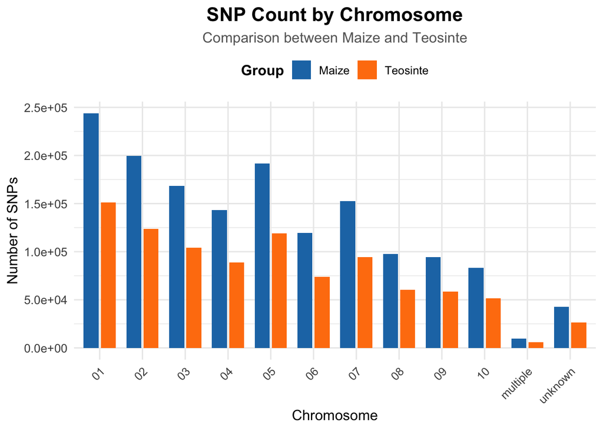

```r
# Count SNPs for each of the maize and teosinte chromosomes
snps_per_chr <- tidy_with_chr %>%
  group_by(Chromosome, type) %>%
  summarise(n = n(), .groups = "drop")
# Plot
ggplot(snps_per_chr, aes(x = Chromosome, y = n, fill = type)) +
  geom_bar(stat = "identity", position = position_dodge(width = 0.8), width = 0.7) +
  scale_fill_manual(values = c("Maize" = "#1f77b4", "Teosinte" = "#ff7f0e")) +
  scale_y_continuous(labels = scales::scientific) +
  labs(
    title = "SNP Count by Chromosome",
    subtitle = "Comparison between Maize and Teosinte",
    x = "Chromosome",
    y = "Number of SNPs",
    fill = "Group"
  ) +
  coord_cartesian(clip = "off") +
  theme_minimal(base_size = 12) +
  theme(
    plot.title = element_text(size = 16, face = "bold", hjust = 0.5),
    plot.subtitle = element_text(size = 12, hjust = 0.5, color = "gray40"),
    axis.text.x = element_text(angle = 45, hjust = 1),
    axis.text.y = element_text(size = 10),
    legend.position = "top",
    legend.title = element_text(face = "bold")
  )
```

##### *There are more SNPs, and hence SNP positions, in Maize compared to Teosinte across all ten chromosomes. Chromosome 01 has the highest number of SNPs, and chromosome 10 the lowest.*

**2.** **Missing Data and Amount of Heterozygosity**:

```r
fang_et_al_genotypes <- read_delim("Common_files/fang_et_al_genotypes.txt",
    delim = "\t", escape_double = FALSE,
    trim_ws = TRUE)
```

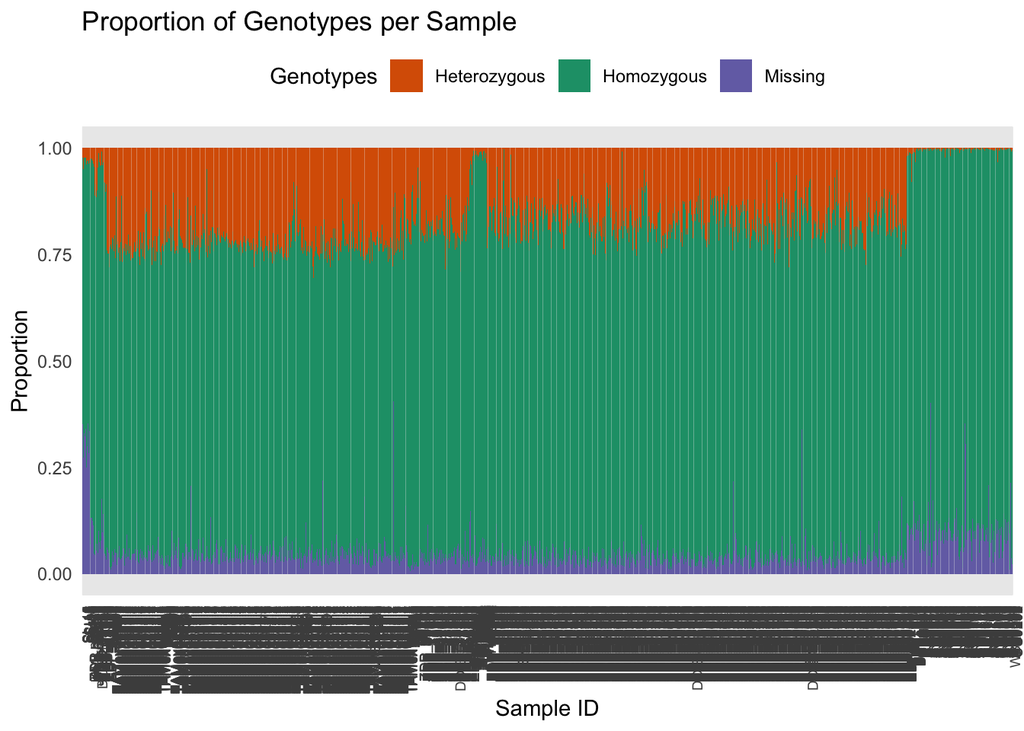

```r
# Make the original data tidy and specify a particular genotype as either homozygous or heterozygous
tidy_fang_genotypes <- fang_et_al_genotypes %>%
  select(-one_of("JG_OTU")) %>%
  pivot_longer(-c(Sample_ID, Group), names_to = "SNP_ID", values_to = "Genotype") %>%
  mutate(
    genotype_type = case_when(
      Genotype %in% c("A/A", "T/T", "C/C", "G/G") ~ "Homozygous",
      Genotype == "?/?" ~ "Missing",
      TRUE ~ "Heterozygous"
    ),
    Sample_ID = factor(Sample_ID, levels = unique(Sample_ID)),  # Ensure correct order
    Group = factor(Group, levels = unique(Group))
  )
# Define custom, friendly colors
friendly_colors <- c(
  "Homozygous" = "#1b9e77",   # Green
  "Heterozygous" = "#d95f02", # Orange
  "Missing" = "#7570b3"       # Purple
)
# Plot 1: Proportion of genotypes per sample
ggplot(tidy_fang_genotypes, aes(x = Sample_ID, fill = genotype_type)) +
  geom_bar(position = "fill") +
  labs(x = "Sample ID", y = "Proportion", title = "Proportion of Genotypes per Sample") +
  scale_fill_manual(name = "Genotypes", values = friendly_colors) +
  theme_minimal() +
  theme(
    axis.text.x = element_text(angle = 90, hjust = 1, size = 7),
    legend.position = "top"
  )
```

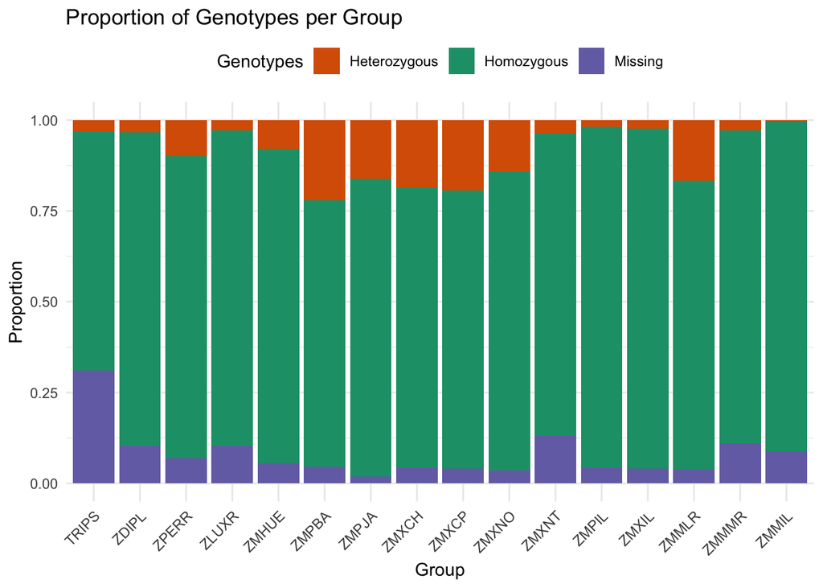

```r
# Plot 2: Proportion of genotypes per group
ggplot(tidy_fang_genotypes, aes(x = Group, fill = genotype_type)) +
  geom_bar(position = "fill") +
  labs(x = "Group", y = "Proportion", title = "Proportion of Genotypes per Group") +
  scale_fill_manual(name = "Genotypes", values = friendly_colors) +
  theme_minimal() +
  theme(
    axis.text.x = element_text(angle = 45, hjust = 1),
    legend.position = "top"
  )
```

**1.** **Distribution of homozygous genotypes in maize groups “ZMMIL,” “ZMMLR,” “ZMMMR” and in teosinte groups “ZMPBA,” “ZMPIL,” “ZMPJA”**:

```r
fang_et_al_genotypes <- read_delim("Common_files/fang_et_al_genotypes.txt",
                                   delim = "\t", escape_double = FALSE, trim_ws = TRUE)
```

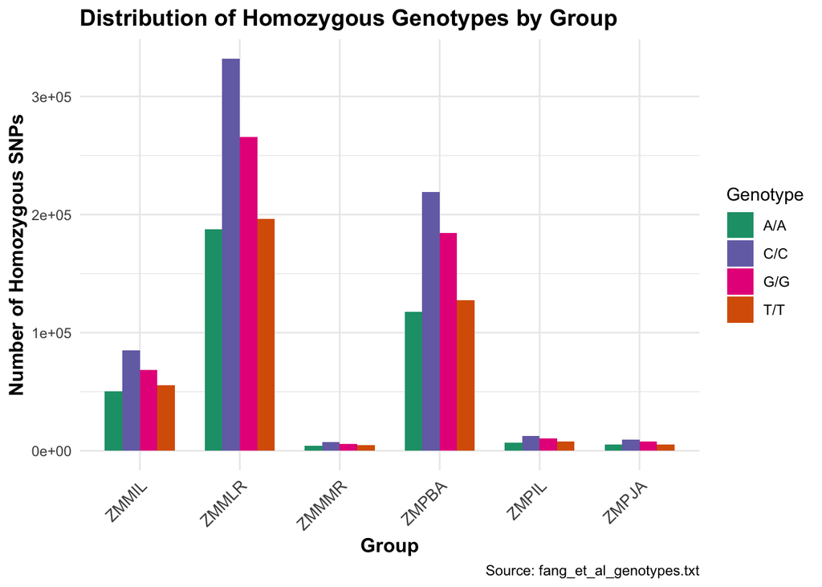

```r
tidy_fang_genotypes <- fang_et_al_genotypes %>%
  select(-one_of("JG_OTU")) %>%
  pivot_longer(-c(Sample_ID, Group), names_to = "SNP_ID", values_to = "Genotype")
# Count homozygous genotypes by Group
genotype_counts <- tidy_fang_genotypes %>%
  count(Group, Genotype)
homozygous_genotypes <- genotype_counts %>%
  filter(Genotype %in% c("A/A", "T/T", "C/C", "G/G"))
# Specify order of groups: Maize groups first (ZMMIL, ZMMLR, ZMMMR), then Teosinte groups (ZMPBA, ZMPIL, ZMPJA)
homozygous_genotypes$Group <- factor(
  homozygous_genotypes$Group,
  levels = c("ZMMIL", "ZMMLR", "ZMMMR", "ZMPBA", "ZMPIL", "ZMPJA")
)
# Exclude NA group from plot
homozygous_genotypes <- homozygous_genotypes %>%
  filter(!is.na(Group))
# Plot Distribution of Homozygous Genotypes by Group
ggplot(homozygous_genotypes, aes(x = Group, y = n, fill = Genotype)) +
  geom_col(position = "dodge", width = 0.7) +
  scale_fill_manual(
    values = c("A/A" = "#1b9e77", "T/T" = "#d95f02", "C/C" = "#7570b3", "G/G" = "#e7298a"),
    name = "Genotype"
  ) +
  labs(
    title = "Distribution of Homozygous Genotypes by Group",
    x = "Group",
    y = "Number of Homozygous SNPs",
    caption = "Source: fang_et_al_genotypes.txt"
  ) +
  theme_minimal() +
  theme(
    axis.text.x = element_text(size = 10, angle = 45, hjust = 1),
    axis.title = element_text(size = 12, face = "bold"),
    plot.title = element_text(size = 14, face = "bold"),
    plot.subtitle = element_text(size = 12, face = "italic")
  )
```